# Risk Factor Analysis

## Outcome Variable

**Outcome Variable:** stunted

## Predictor Variables

**Intervention Variable:** mhtcm

**Adjustment Set:**

unadjusted

## Stratifying Variables

The analysis was stratified on these variable(s):

- agecat
- studyid

The following strata were considered:

- agecat: 12 months, studyid: ki0047075b-MAL-ED
- agecat: 12 months, studyid: ki1000304b-SAS-FoodSuppl
- agecat: 12 months, studyid: ki1017093-NIH-Birth
- agecat: 12 months, studyid: ki1017093b-PROVIDE
- agecat: 12 months, studyid: ki1017093c-NIH-Crypto
- agecat: 12 months, studyid: ki1066203-TanzaniaChild2
- agecat: 12 months, studyid: ki1101329-Keneba
- agecat: 12 months, studyid: ki1112895-Guatemala BSC
- agecat: 12 months, studyid: ki1126311-ZVITAMBO
- agecat: 12 months, studyid: ki1135781-COHORTS
- agecat: 12 months, studyid: ki1148112-LCNI-5
- agecat: 18 months, studyid: ki0047075b-MAL-ED
- agecat: 18 months, studyid: ki1000304b-SAS-FoodSuppl
- agecat: 18 months, studyid: ki1017093-NIH-Birth
- agecat: 18 months, studyid: ki1017093b-PROVIDE
- agecat: 18 months, studyid: ki1017093c-NIH-Crypto
- agecat: 18 months, studyid: ki1066203-TanzaniaChild2
- agecat: 18 months, studyid: ki1101329-Keneba
- agecat: 18 months, studyid: ki1126311-ZVITAMBO
- agecat: 18 months, studyid: ki1135781-COHORTS
- agecat: 18 months, studyid: ki1148112-LCNI-5
- agecat: 24 months, studyid: ki0047075b-MAL-ED
- agecat: 24 months, studyid: ki1017093-NIH-Birth
- agecat: 24 months, studyid: ki1017093b-PROVIDE
- agecat: 24 months, studyid: ki1017093c-NIH-Crypto
- agecat: 24 months, studyid: ki1066203-TanzaniaChild2
- agecat: 24 months, studyid: ki1101329-Keneba
- agecat: 24 months, studyid: ki1126311-ZVITAMBO
- agecat: 24 months, studyid: ki1135781-COHORTS
- agecat: 24 months, studyid: ki1148112-LCNI-5
- agecat: 3 months, studyid: ki0047075b-MAL-ED
- agecat: 3 months, studyid: ki1000304b-SAS-FoodSuppl
- agecat: 3 months, studyid: ki1017093-NIH-Birth
- agecat: 3 months, studyid: ki1017093b-PROVIDE
- agecat: 3 months, studyid: ki1017093c-NIH-Crypto
- agecat: 3 months, studyid: ki1066203-TanzaniaChild2
- agecat: 3 months, studyid: ki1101329-Keneba
- agecat: 3 months, studyid: ki1112895-Guatemala BSC
- agecat: 3 months, studyid: ki1126311-ZVITAMBO
- agecat: 3 months, studyid: ki1135781-COHORTS
- agecat: 6 months, studyid: ki0047075b-MAL-ED
- agecat: 6 months, studyid: ki1000304b-SAS-FoodSuppl
- agecat: 6 months, studyid: ki1017093-NIH-Birth
- agecat: 6 months, studyid: ki1017093b-PROVIDE
- agecat: 6 months, studyid: ki1017093c-NIH-Crypto
- agecat: 6 months, studyid: ki1066203-TanzaniaChild2
- agecat: 6 months, studyid: ki1101329-Keneba
- agecat: 6 months, studyid: ki1112895-Guatemala BSC
- agecat: 6 months, studyid: ki1126311-ZVITAMBO
- agecat: 6 months, studyid: ki1135781-COHORTS
- agecat: 6 months, studyid: ki1148112-LCNI-5
- agecat: 9 months, studyid: ki0047075b-MAL-ED
- agecat: 9 months, studyid: ki1000304b-SAS-FoodSuppl
- agecat: 9 months, studyid: ki1017093-NIH-Birth
- agecat: 9 months, studyid: ki1017093b-PROVIDE
- agecat: 9 months, studyid: ki1017093c-NIH-Crypto
- agecat: 9 months, studyid: ki1066203-TanzaniaChild2
- agecat: 9 months, studyid: ki1101329-Keneba
- agecat: 9 months, studyid: ki1112895-Guatemala BSC
- agecat: 9 months, studyid: ki1126311-ZVITAMBO
- agecat: 9 months, studyid: ki1135781-COHORTS
- agecat: 9 months, studyid: ki1148112-LCNI-5
- agecat: Birth, studyid: ki0047075b-MAL-ED
- agecat: Birth, studyid: ki1017093-NIH-Birth
- agecat: Birth, studyid: ki1017093c-NIH-Crypto
- agecat: Birth, studyid: ki1101329-Keneba
- agecat: Birth, studyid: ki1126311-ZVITAMBO
- agecat: Birth, studyid: ki1135781-COHORTS

### Dropped Strata

Some strata were dropped due to rare outcomes:

- agecat: Birth, studyid: ki1017093-NIH-Birth
- agecat: Birth, studyid: ki1017093c-NIH-Crypto
- agecat: Birth, studyid: ki1101329-Keneba
- agecat: 3 months, studyid: ki1000304b-SAS-FoodSuppl
- agecat: 3 months, studyid: ki1017093-NIH-Birth
- agecat: 3 months, studyid: ki1017093b-PROVIDE
- agecat: 3 months, studyid: ki1017093c-NIH-Crypto
- agecat: 3 months, studyid: ki1112895-Guatemala BSC
- agecat: 6 months, studyid: ki1000304b-SAS-FoodSuppl
- agecat: 6 months, studyid: ki1017093-NIH-Birth
- agecat: 6 months, studyid: ki1017093b-PROVIDE
- agecat: 6 months, studyid: ki1017093c-NIH-Crypto
- agecat: 6 months, studyid: ki1112895-Guatemala BSC
- agecat: 9 months, studyid: ki1000304b-SAS-FoodSuppl
- agecat: 9 months, studyid: ki1017093-NIH-Birth
- agecat: 9 months, studyid: ki1017093b-PROVIDE
- agecat: 9 months, studyid: ki1017093c-NIH-Crypto
- agecat: 9 months, studyid: ki1112895-Guatemala BSC
- agecat: 12 months, studyid: ki1000304b-SAS-FoodSuppl
- agecat: 12 months, studyid: ki1017093-NIH-Birth
- agecat: 12 months, studyid: ki1017093b-PROVIDE
- agecat: 12 months, studyid: ki1017093c-NIH-Crypto
- agecat: 12 months, studyid: ki1112895-Guatemala BSC
- agecat: 18 months, studyid: ki1000304b-SAS-FoodSuppl
- agecat: 18 months, studyid: ki1017093-NIH-Birth
- agecat: 18 months, studyid: ki1017093b-PROVIDE
- agecat: 18 months, studyid: ki1017093c-NIH-Crypto
- agecat: 18 months, studyid: ki1126311-ZVITAMBO
- agecat: 24 months, studyid: ki1017093-NIH-Birth
- agecat: 24 months, studyid: ki1017093b-PROVIDE
- agecat: 24 months, studyid: ki1017093c-NIH-Crypto
- agecat: 24 months, studyid: ki1066203-TanzaniaChild2
- agecat: 24 months, studyid: ki1126311-ZVITAMBO

## Methods Detail

We’re interested in the causal parameters $E[Y_a]$ for all values of $a \in \mathcal{A}$. These parameters represent the mean outcome if, possibly contrary to fact, we intervened to set all units to have $A=a$. Under the randomization and positivity assumptions, these are identified by the statistical parameters $\psi_a=E_W[E_{Y|A,W}(Y|A=a,W)]$. In addition, we’re interested in the mean of $Y$, $E[Y]$ under no intervention (the observed mean). We will estimate these parameters by using SuperLearner to fit the relevant likelihood factors – $E_{Y|A,W}(Y|A=a,W)$ and $p(A=a|W)$, and then updating our likelihood fit using a joint TMLE.

For unadjusted analyses ($W=\{\}$), initial likelihoods were estimated using Lrnr_glm to estimate the simple $E(Y|A)$ and Lrnr_mean to estimate $p(A)$. For adjusted analyses, a small library containing Lrnr_glmnet, Lrnr_xgboost, and Lrnr_mean was used.

Having estimated these parameters, we will then use the delta method to estimate relative risks and attributable risks relative to a prespecified baseline level of $A$.

# Results Detail

## Results Plots

[figure not shown]

[figure not shown]

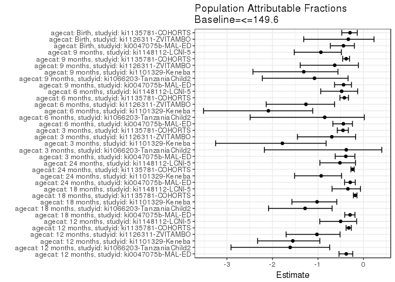

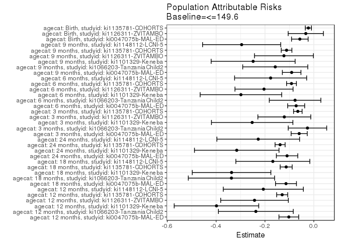

## Data Summary

| agecat | studyid | A | n | nA | nAY0 | nAY1 |
| --- | --- | --- | --- | --- | --- | --- |
| Birth | ki0047075b-MAL-ED | <=149.6 | 1425 | 508 | 413 | 95 |
| Birth | ki0047075b-MAL-ED | (149.6-154.9] | 1425 | 405 | 360 | 45 |
| Birth | ki0047075b-MAL-ED | (154.9-160.8] | 1425 | 334 | 301 | 33 |
| Birth | ki0047075b-MAL-ED | >160.8 | 1425 | 178 | 166 | 12 |
| Birth | ki1000304b-SAS-FoodSuppl | <=149.6 | 0 | 0 | 0 | 0 |
| Birth | ki1000304b-SAS-FoodSuppl | (149.6-154.9] | 0 | 0 | 0 | 0 |
| Birth | ki1000304b-SAS-FoodSuppl | (154.9-160.8] | 0 | 0 | 0 | 0 |
| Birth | ki1000304b-SAS-FoodSuppl | >160.8 | 0 | 0 | 0 | 0 |
| Birth | ki1017093-NIH-Birth | <=149.6 | 28 | 14 | 14 | 0 |
| Birth | ki1017093-NIH-Birth | (149.6-154.9] | 28 | 7 | 6 | 1 |
| Birth | ki1017093-NIH-Birth | (154.9-160.8] | 28 | 7 | 7 | 0 |
| Birth | ki1017093-NIH-Birth | >160.8 | 28 | 0 | 0 | 0 |
| Birth | ki1017093b-PROVIDE | <=149.6 | 0 | 0 | 0 | 0 |
| Birth | ki1017093b-PROVIDE | (149.6-154.9] | 0 | 0 | 0 | 0 |
| Birth | ki1017093b-PROVIDE | (154.9-160.8] | 0 | 0 | 0 | 0 |
| Birth | ki1017093b-PROVIDE | >160.8 | 0 | 0 | 0 | 0 |
| Birth | ki1017093c-NIH-Crypto | <=149.6 | 27 | 14 | 12 | 2 |
| Birth | ki1017093c-NIH-Crypto | (149.6-154.9] | 27 | 9 | 6 | 3 |
| Birth | ki1017093c-NIH-Crypto | (154.9-160.8] | 27 | 3 | 3 | 0 |
| Birth | ki1017093c-NIH-Crypto | >160.8 | 27 | 1 | 1 | 0 |
| Birth | ki1066203-TanzaniaChild2 | <=149.6 | 0 | 0 | 0 | 0 |
| Birth | ki1066203-TanzaniaChild2 | (149.6-154.9] | 0 | 0 | 0 | 0 |
| Birth | ki1066203-TanzaniaChild2 | (154.9-160.8] | 0 | 0 | 0 | 0 |
| Birth | ki1066203-TanzaniaChild2 | >160.8 | 0 | 0 | 0 | 0 |
| Birth | ki1101329-Keneba | <=149.6 | 1429 | 23 | 21 | 2 |
| Birth | ki1101329-Keneba | (149.6-154.9] | 1429 | 220 | 206 | 14 |
| Birth | ki1101329-Keneba | (154.9-160.8] | 1429 | 548 | 522 | 26 |
| Birth | ki1101329-Keneba | >160.8 | 1429 | 638 | 608 | 30 |
| Birth | ki1112895-Guatemala BSC | <=149.6 | 0 | 0 | 0 | 0 |
| Birth | ki1112895-Guatemala BSC | (149.6-154.9] | 0 | 0 | 0 | 0 |

[output cut: 278 more lines]

## Results Table

### Parameter: TSM

| agecat | studyid | intervention_level | baseline_level | estimate | ci_lower | ci_upper |
| --- | --- | --- | --- | --- | --- | --- |
| Birth | ki0047075b-MAL-ED | <=149.6 | NA | 0.1870079 | 0.1530890 | 0.2209268 |
| Birth | ki0047075b-MAL-ED | (149.6-154.9] | NA | 0.1111111 | 0.0804932 | 0.1417290 |
| Birth | ki0047075b-MAL-ED | (154.9-160.8] | NA | 0.0988024 | 0.0667898 | 0.1308150 |
| Birth | ki0047075b-MAL-ED | >160.8 | NA | 0.0674157 | 0.0305676 | 0.1042638 |
| Birth | ki1126311-ZVITAMBO | <=149.6 | NA | 0.1309524 | 0.0587955 | 0.2031093 |
| Birth | ki1126311-ZVITAMBO | (149.6-154.9] | NA | 0.1188630 | 0.0866131 | 0.1511130 |
| Birth | ki1126311-ZVITAMBO | (154.9-160.8] | NA | 0.1053241 | 0.0848512 | 0.1257969 |
| Birth | ki1126311-ZVITAMBO | >160.8 | NA | 0.0822306 | 0.0656737 | 0.0987875 |
| Birth | ki1135781-COHORTS | <=149.6 | NA | 0.0968201 | 0.0841923 | 0.1094479 |
| Birth | ki1135781-COHORTS | (149.6-154.9] | NA | 0.0692550 | 0.0578559 | 0.0806540 |
| Birth | ki1135781-COHORTS | (154.9-160.8] | NA | 0.0459540 | 0.0329817 | 0.0589264 |
| Birth | ki1135781-COHORTS | >160.8 | NA | 0.0386474 | 0.0123867 | 0.0649080 |
| 3 months | ki0047075b-MAL-ED | <=149.6 | NA | 0.2138047 | 0.1808246 | 0.2467848 |
| 3 months | ki0047075b-MAL-ED | (149.6-154.9] | NA | 0.1317365 | 0.1021134 | 0.1613597 |
| 3 months | ki0047075b-MAL-ED | (154.9-160.8] | NA | 0.1376147 | 0.1052694 | 0.1699600 |
| 3 months | ki0047075b-MAL-ED | >160.8 | NA | 0.0786026 | 0.0437371 | 0.1134681 |
| 3 months | ki1066203-TanzaniaChild2 | <=149.6 | NA | 0.0943396 | 0.0155768 | 0.1731024 |
| 3 months | ki1066203-TanzaniaChild2 | (149.6-154.9] | NA | 0.0855263 | 0.0410281 | 0.1300246 |
| 3 months | ki1066203-TanzaniaChild2 | (154.9-160.8] | NA | 0.0686695 | 0.0361694 | 0.1011697 |
| 3 months | ki1066203-TanzaniaChild2 | >160.8 | NA | 0.0378788 | 0.0052835 | 0.0704741 |
| 3 months | ki1101329-Keneba | <=149.6 | NA | 0.3939394 | 0.2271858 | 0.5606930 |
| 3 months | ki1101329-Keneba | (149.6-154.9] | NA | 0.2359155 | 0.1865243 | 0.2853067 |
| 3 months | ki1101329-Keneba | (154.9-160.8] | NA | 0.1496063 | 0.1242744 | 0.1749382 |
| 3 months | ki1101329-Keneba | >160.8 | NA | 0.0942529 | 0.0748328 | 0.1136729 |
| 3 months | ki1126311-ZVITAMBO | <=149.6 | NA | 0.2941176 | 0.1857915 | 0.4024437 |
| 3 months | ki1126311-ZVITAMBO | (149.6-154.9] | NA | 0.2098765 | 0.1655241 | 0.2542290 |
| 3 months | ki1126311-ZVITAMBO | (154.9-160.8] | NA | 0.1869565 | 0.1578585 | 0.2160545 |
| 3 months | ki1126311-ZVITAMBO | >160.8 | NA | 0.1386256 | 0.1153067 | 0.1619445 |
| 3 months | ki1135781-COHORTS | <=149.6 | NA | 0.2107262 | 0.1933108 | 0.2281415 |
| 3 months | ki1135781-COHORTS | (149.6-154.9] | NA | 0.1136241 | 0.0991887 | 0.1280595 |

[output cut: 110 more lines]

### Parameter: E(Y)

| agecat | studyid | intervention_level | baseline_level | estimate | ci_lower | ci_upper |
| --- | --- | --- | --- | --- | --- | --- |
| Birth | ki0047075b-MAL-ED | NA | NA | 0.1298246 | 0.1275150 | 0.1321341 |
| Birth | ki1126311-ZVITAMBO | NA | NA | 0.0982031 | 0.0975851 | 0.0988210 |
| Birth | ki1135781-COHORTS | NA | NA | 0.0746983 | 0.0741435 | 0.0752531 |
| 3 months | ki0047075b-MAL-ED | NA | NA | 0.1539773 | 0.1518082 | 0.1561464 |
| 3 months | ki1066203-TanzaniaChild2 | NA | NA | 0.0684211 | 0.0668696 | 0.0699725 |
| 3 months | ki1101329-Keneba | NA | NA | 0.1416111 | 0.1390217 | 0.1442005 |
| 3 months | ki1126311-ZVITAMBO | NA | NA | 0.1734164 | 0.1717848 | 0.1750481 |
| 3 months | ki1135781-COHORTS | NA | NA | 0.1453488 | 0.1438159 | 0.1468817 |
| 6 months | ki0047075b-MAL-ED | NA | NA | 0.1634103 | 0.1608313 | 0.1659893 |
| 6 months | ki1066203-TanzaniaChild2 | NA | NA | 0.0900000 | 0.0873870 | 0.0926130 |
| 6 months | ki1101329-Keneba | NA | NA | 0.1427810 | 0.1400172 | 0.1455449 |
| 6 months | ki1126311-ZVITAMBO | NA | NA | 0.1611991 | 0.1586066 | 0.1637916 |
| 6 months | ki1135781-COHORTS | NA | NA | 0.2168675 | 0.2146475 | 0.2190875 |
| 6 months | ki1148112-LCNI-5 | NA | NA | 0.3686747 | 0.3600157 | 0.3773337 |
| 9 months | ki0047075b-MAL-ED | NA | NA | 0.2068543 | 0.2035204 | 0.2101883 |
| 9 months | ki1066203-TanzaniaChild2 | NA | NA | 0.1465116 | 0.1407467 | 0.1522766 |
| 9 months | ki1101329-Keneba | NA | NA | 0.1891026 | 0.1859742 | 0.1922309 |
| 9 months | ki1126311-ZVITAMBO | NA | NA | 0.1935484 | 0.1920502 | 0.1950465 |
| 9 months | ki1135781-COHORTS | NA | NA | 0.2927947 | 0.2900283 | 0.2955611 |
| 9 months | ki1148112-LCNI-5 | NA | NA | 0.3156250 | 0.3026529 | 0.3285971 |
| 12 months | ki0047075b-MAL-ED | NA | NA | 0.2695652 | 0.2657967 | 0.2733338 |
| 12 months | ki1066203-TanzaniaChild2 | NA | NA | 0.1473088 | 0.1368109 | 0.1578067 |
| 12 months | ki1101329-Keneba | NA | NA | 0.2566272 | 0.2524766 | 0.2607778 |
| 12 months | ki1126311-ZVITAMBO | NA | NA | 0.2372765 | 0.2341146 | 0.2404383 |
| 12 months | ki1135781-COHORTS | NA | NA | 0.3987465 | 0.3952763 | 0.4022167 |
| 12 months | ki1148112-LCNI-5 | NA | NA | 0.4110032 | 0.3996986 | 0.4223079 |
| 18 months | ki0047075b-MAL-ED | NA | NA | 0.3861129 | 0.3818036 | 0.3904222 |
| 18 months | ki1066203-TanzaniaChild2 | NA | NA | 0.2627451 | 0.2440908 | 0.2813994 |
| 18 months | ki1101329-Keneba | NA | NA | 0.3299492 | 0.3255952 | 0.3343032 |
| 18 months | ki1135781-COHORTS | NA | NA | 0.6234079 | 0.6191926 | 0.6276233 |
| 18 months | ki1148112-LCNI-5 | NA | NA | 0.4901408 | 0.4789801 | 0.5013016 |
| 24 months | ki0047075b-MAL-ED | NA | NA | 0.3746631 | 0.3705718 | 0.3787544 |
| 24 months | ki1101329-Keneba | NA | NA | 0.3395755 | 0.3345476 | 0.3446034 |
| 24 months | ki1135781-COHORTS | NA | NA | 0.5765823 | 0.5726317 | 0.5805329 |
| 24 months | ki1148112-LCNI-5 | NA | NA | 0.4391892 | 0.4280652 | 0.4503131 |

### Parameter: RR

| agecat | studyid | intervention_level | baseline_level | estimate | ci_lower | ci_upper |
| --- | --- | --- | --- | --- | --- | --- |
| Birth | ki0047075b-MAL-ED | (149.6-154.9] | <=149.6 | 0.5941520 | 0.4271943 | 0.8263608 |
| Birth | ki0047075b-MAL-ED | (154.9-160.8] | <=149.6 | 0.5283328 | 0.3644566 | 0.7658951 |
| Birth | ki0047075b-MAL-ED | >160.8 | <=149.6 | 0.3604967 | 0.2026731 | 0.6412192 |
| Birth | ki1126311-ZVITAMBO | (149.6-154.9] | <=149.6 | 0.9076815 | 0.4911258 | 1.6775450 |
| Birth | ki1126311-ZVITAMBO | (154.9-160.8] | <=149.6 | 0.8042929 | 0.4483917 | 1.4426831 |
| Birth | ki1126311-ZVITAMBO | >160.8 | <=149.6 | 0.6279429 | 0.3492536 | 1.1290145 |
| Birth | ki1135781-COHORTS | (149.6-154.9] | <=149.6 | 0.7152954 | 0.5798038 | 0.8824493 |
| Birth | ki1135781-COHORTS | (154.9-160.8] | <=149.6 | 0.4746332 | 0.3477830 | 0.6477507 |
| Birth | ki1135781-COHORTS | >160.8 | <=149.6 | 0.3991665 | 0.1998326 | 0.7973368 |
| 3 months | ki0047075b-MAL-ED | (149.6-154.9] | <=149.6 | 0.6161535 | 0.4690959 | 0.8093124 |
| 3 months | ki0047075b-MAL-ED | (154.9-160.8] | <=149.6 | 0.6436466 | 0.4859039 | 0.8525986 |
| 3 months | ki0047075b-MAL-ED | >160.8 | <=149.6 | 0.3676375 | 0.2298610 | 0.5879958 |
| 3 months | ki1066203-TanzaniaChild2 | (149.6-154.9] | <=149.6 | 0.9065789 | 0.3389809 | 2.4245773 |
| 3 months | ki1066203-TanzaniaChild2 | (154.9-160.8] | <=149.6 | 0.7278970 | 0.2787891 | 1.9004831 |
| 3 months | ki1066203-TanzaniaChild2 | >160.8 | <=149.6 | 0.4015152 | 0.1210590 | 1.3317016 |
| 3 months | ki1101329-Keneba | (149.6-154.9] | <=149.6 | 0.5988624 | 0.3734522 | 0.9603269 |
| 3 months | ki1101329-Keneba | (154.9-160.8] | <=149.6 | 0.3797698 | 0.2407257 | 0.5991264 |
| 3 months | ki1101329-Keneba | >160.8 | <=149.6 | 0.2392573 | 0.1494197 | 0.3831092 |
| 3 months | ki1126311-ZVITAMBO | (149.6-154.9] | <=149.6 | 0.7135802 | 0.4666901 | 1.0910812 |
| 3 months | ki1126311-ZVITAMBO | (154.9-160.8] | <=149.6 | 0.6356522 | 0.4261568 | 0.9481338 |
| 3 months | ki1126311-ZVITAMBO | >160.8 | <=149.6 | 0.4713270 | 0.3143943 | 0.7065942 |
| 3 months | ki1135781-COHORTS | (149.6-154.9] | <=149.6 | 0.5392028 | 0.4633726 | 0.6274425 |
| 3 months | ki1135781-COHORTS | (154.9-160.8] | <=149.6 | 0.4040719 | 0.3247915 | 0.5027044 |
| 3 months | ki1135781-COHORTS | >160.8 | <=149.6 | 0.2296208 | 0.1207488 | 0.4366559 |
| 6 months | ki0047075b-MAL-ED | (149.6-154.9] | <=149.6 | 0.5799862 | 0.4434537 | 0.7585549 |
| 6 months | ki0047075b-MAL-ED | (154.9-160.8] | <=149.6 | 0.5727443 | 0.4307760 | 0.7615002 |
| 6 months | ki0047075b-MAL-ED | >160.8 | <=149.6 | 0.3699287 | 0.2348531 | 0.5826929 |
| 6 months | ki1066203-TanzaniaChild2 | (149.6-154.9] | <=149.6 | 0.6131387 | 0.2741656 | 1.3712115 |
| 6 months | ki1066203-TanzaniaChild2 | (154.9-160.8] | <=149.6 | 0.4927536 | 0.2258262 | 1.0751901 |
| 6 months | ki1066203-TanzaniaChild2 | >160.8 | <=149.6 | 0.3333333 | 0.1222085 | 0.9091927 |

[output cut: 75 more lines]

### Parameter: PAR

| agecat | studyid | intervention_level | baseline_level | estimate | ci_lower | ci_upper |
| --- | --- | --- | --- | --- | --- | --- |
| Birth | ki0047075b-MAL-ED | <=149.6 | NA | -0.0571833 | -0.0911808 | -0.0231859 |
| Birth | ki1126311-ZVITAMBO | <=149.6 | NA | -0.0327493 | -0.1049088 | 0.0394102 |
| Birth | ki1135781-COHORTS | <=149.6 | NA | -0.0221218 | -0.0347618 | -0.0094818 |
| 3 months | ki0047075b-MAL-ED | <=149.6 | NA | -0.0598274 | -0.0928788 | -0.0267761 |
| 3 months | ki1066203-TanzaniaChild2 | <=149.6 | NA | -0.0259186 | -0.1046967 | 0.0528595 |
| 3 months | ki1101329-Keneba | <=149.6 | NA | -0.2523283 | -0.4191020 | -0.0855546 |
| 3 months | ki1126311-ZVITAMBO | <=149.6 | NA | -0.1207012 | -0.2290396 | -0.0123629 |
| 3 months | ki1135781-COHORTS | <=149.6 | NA | -0.0653773 | -0.0828599 | -0.0478947 |
| 6 months | ki0047075b-MAL-ED | <=149.6 | NA | -0.0721918 | -0.1070449 | -0.0373387 |
| 6 months | ki1066203-TanzaniaChild2 | <=149.6 | NA | -0.0766667 | -0.1822339 | 0.0289005 |
| 6 months | ki1101329-Keneba | <=149.6 | NA | -0.2983954 | -0.4653612 | -0.1314297 |
| 6 months | ki1126311-ZVITAMBO | <=149.6 | NA | -0.2038803 | -0.3228283 | -0.0849323 |
| 6 months | ki1135781-COHORTS | <=149.6 | NA | -0.0913179 | -0.1115384 | -0.0710974 |
| 6 months | ki1148112-LCNI-5 | <=149.6 | NA | -0.1767798 | -0.3243378 | -0.0292219 |
| 9 months | ki0047075b-MAL-ED | <=149.6 | NA | -0.0906367 | -0.1287255 | -0.0525479 |
| 9 months | ki1066203-TanzaniaChild2 | <=149.6 | NA | -0.1578362 | -0.2910848 | -0.0245876 |
| 9 months | ki1101329-Keneba | <=149.6 | NA | -0.2483974 | -0.4203510 | -0.0764438 |
| 9 months | ki1126311-ZVITAMBO | <=149.6 | NA | -0.1222411 | -0.2429578 | -0.0015243 |
| 9 months | ki1135781-COHORTS | <=149.6 | NA | -0.1114715 | -0.1333258 | -0.0896171 |
| 9 months | ki1148112-LCNI-5 | <=149.6 | NA | -0.2954861 | -0.4555086 | -0.1354636 |
| 12 months | ki0047075b-MAL-ED | <=149.6 | NA | -0.1022759 | -0.1427090 | -0.0618429 |
| 12 months | ki1066203-TanzaniaChild2 | <=149.6 | NA | -0.2373066 | -0.3905704 | -0.0840428 |
| 12 months | ki1101329-Keneba | <=149.6 | NA | -0.3985452 | -0.5716366 | -0.2254539 |
| 12 months | ki1126311-ZVITAMBO | <=149.6 | NA | -0.2427235 | -0.3812867 | -0.1041603 |
| 12 months | ki1135781-COHORTS | <=149.6 | NA | -0.1294962 | -0.1521420 | -0.1068504 |
| 12 months | ki1148112-LCNI-5 | <=149.6 | NA | -0.2066438 | -0.3706458 | -0.0426418 |
| 18 months | ki0047075b-MAL-ED | <=149.6 | NA | -0.1138871 | -0.1568469 | -0.0709273 |
| 18 months | ki1066203-TanzaniaChild2 | <=149.6 | NA | -0.3372549 | -0.5138919 | -0.1606179 |
| 18 months | ki1101329-Keneba | <=149.6 | NA | -0.3367174 | -0.4976583 | -0.1757766 |
| 18 months | ki1135781-COHORTS | <=149.6 | NA | -0.1130627 | -0.1376130 | -0.0885123 |
| 18 months | ki1148112-LCNI-5 | <=149.6 | NA | -0.1677539 | -0.3192178 | -0.0162900 |
| 24 months | ki0047075b-MAL-ED | <=149.6 | NA | -0.1094639 | -0.1532998 | -0.0656280 |
| 24 months | ki1101329-Keneba | <=149.6 | NA | -0.3155969 | -0.4887167 | -0.1424771 |
| 24 months | ki1135781-COHORTS | <=149.6 | NA | -0.1380011 | -0.1585864 | -0.1174157 |
| 24 months | ki1148112-LCNI-5 | <=149.6 | NA | -0.2274775 | -0.3968158 | -0.0581392 |

### Parameter: PAF

| agecat | studyid | intervention_level | baseline_level | estimate | ci_lower | ci_upper |
| --- | --- | --- | --- | --- | --- | --- |
| Birth | ki0047075b-MAL-ED | <=149.6 | NA | -0.4404661 | -0.7284308 | -0.2004776 |
| Birth | ki1126311-ZVITAMBO | <=149.6 | NA | -0.3334853 | -1.3137003 | 0.2314549 |
| Birth | ki1135781-COHORTS | <=149.6 | NA | -0.2961484 | -0.4770305 | -0.1374177 |
| 3 months | ki0047075b-MAL-ED | <=149.6 | NA | -0.3885472 | -0.6211785 | -0.1892974 |
| 3 months | ki1066203-TanzaniaChild2 | <=149.6 | NA | -0.3788099 | -2.1785158 | 0.4018854 |
| 3 months | ki1101329-Keneba | <=149.6 | NA | -1.7818401 | -3.2495158 | -0.8210626 |
| 3 months | ki1126311-ZVITAMBO | <=149.6 | NA | -0.6960197 | -1.4515318 | -0.1733410 |
| 3 months | ki1135781-COHORTS | <=149.6 | NA | -0.4497959 | -0.5757593 | -0.3339018 |
| 6 months | ki0047075b-MAL-ED | <=149.6 | NA | -0.4417824 | -0.6723808 | -0.2429803 |
| 6 months | ki1066203-TanzaniaChild2 | <=149.6 | NA | -0.8518519 | -2.4905544 | 0.0175328 |
| 6 months | ki1101329-Keneba | <=149.6 | NA | -2.0898815 | -3.5133124 | -1.1153793 |
| 6 months | ki1126311-ZVITAMBO | <=149.6 | NA | -1.2647730 | -2.1380704 | -0.6345067 |
| 6 months | ki1135781-COHORTS | <=149.6 | NA | -0.4210771 | -0.5180529 | -0.3302964 |
| 6 months | ki1148112-LCNI-5 | <=149.6 | NA | -0.4795009 | -0.9401804 | -0.1282059 |
| 9 months | ki0047075b-MAL-ED | <=149.6 | NA | -0.4381667 | -0.6354622 | -0.2646722 |
| 9 months | ki1066203-TanzaniaChild2 | <=149.6 | NA | -1.0772947 | -2.2227649 | -0.3389599 |
| 9 months | ki1101329-Keneba | <=149.6 | NA | -1.3135593 | -2.4284457 | -0.5612196 |
| 9 months | ki1126311-ZVITAMBO | <=149.6 | NA | -0.6315789 | -1.3913711 | -0.1131898 |
| 9 months | ki1135781-COHORTS | <=149.6 | NA | -0.3807155 | -0.4579805 | -0.3075450 |
| 9 months | ki1148112-LCNI-5 | <=149.6 | NA | -0.9361936 | -1.5217004 | -0.4866341 |
| 12 months | ki0047075b-MAL-ED | <=149.6 | NA | -0.3794107 | -0.5385175 | -0.2367581 |
| 12 months | ki1066203-TanzaniaChild2 | <=149.6 | NA | -1.6109467 | -2.9102441 | -0.7433804 |
| 12 months | ki1101329-Keneba | <=149.6 | NA | -1.5530125 | -2.3263807 | -0.9594489 |
| 12 months | ki1126311-ZVITAMBO | <=149.6 | NA | -1.0229565 | -1.7005776 | -0.5153621 |
| 12 months | ki1135781-COHORTS | <=149.6 | NA | -0.3247582 | -0.3833088 | -0.2686858 |
| 12 months | ki1148112-LCNI-5 | <=149.6 | NA | -0.5027791 | -0.9613553 | -0.1514206 |
| 18 months | ki0047075b-MAL-ED | <=149.6 | NA | -0.2949580 | -0.4115522 | -0.1879945 |
| 18 months | ki1066203-TanzaniaChild2 | <=149.6 | NA | -1.2835821 | -2.0863226 | -0.6896313 |
| 18 months | ki1101329-Keneba | <=149.6 | NA | -1.0205128 | -1.5729030 | -0.5867182 |
| 18 months | ki1135781-COHORTS | <=149.6 | NA | -0.1813623 | -0.2216437 | -0.1424090 |
| 18 months | ki1148112-LCNI-5 | <=149.6 | NA | -0.3422565 | -0.6905904 | -0.0656943 |
| 24 months | ki0047075b-MAL-ED | <=149.6 | NA | -0.2921663 | -0.4150008 | -0.1799948 |
| 24 months | ki1101329-Keneba | <=149.6 | NA | -0.9293864 | -1.5136622 | -0.4809197 |
| 24 months | ki1135781-COHORTS | <=149.6 | NA | -0.2393432 | -0.2759258 | -0.2038095 |
| 24 months | ki1148112-LCNI-5 | <=149.6 | NA | -0.5179487 | -0.9583084 | -0.1766115 |